# Práctica I

## Ejercicio 5.2

> Obtén los autovectores (por columnas). Escribe de manera explícita la expresión de la tres primeras componentes (como combinación lineal de las variables originales).

```r
pca_fit$svd$V # autovectores (por columnas)
```

```
              [,1]        [,2]         [,3]         [,4]         [,5]
 [1,] -0.044996564  0.23465060  0.456302477  0.352123379 -0.014476955
 [2,] -0.050170983 -0.41402574 -0.182077268 -0.015918841 -0.169487301
 [3,]  0.055530972  0.39016851  0.306165578 -0.004710738  0.111056329
 [4,]  0.167396487 -0.23231478 -0.128784859 -0.058004327  0.477123964
 [5,]  0.009221178 -0.26339675  0.494825233 -0.344163934 -0.175975821
 [6,]  0.155760985  0.17710005 -0.317187535 -0.260012233  0.124660104
 [7,] -0.170762591 -0.06647268 -0.419173508  0.406611333 -0.154947089
 [8,] -0.211760742  0.26706730 -0.180814523  0.103607494 -0.106003198
 [9,]  0.204597946 -0.30159006  0.138422526 -0.032640620  0.070923329
[10,]  0.040589364 -0.18881760  0.170431585  0.556257709 -0.288138696
[11,] -0.273128453  0.03941863 -0.013477934  0.077068153  0.181427645
[12,]  0.286512091 -0.00946142 -0.009549039  0.024920808 -0.026849358
[13,]  0.285762218  0.02847863  0.009670192  0.009705899 -0.010694697
[14,]  0.282631644 -0.05825777 -0.031678065  0.039365938 -0.046282060
```

[output cut: 105 more lines]

```r
# los autovectores (loadings) son las coordenadas de las componentes respecto a las variabs orig

pca_fit$svd$V[ ,1] # coords de la comp 1
```

```
 [1] -0.044996564 -0.050170983  0.055530972  0.167396487  0.009221178
 [6]  0.155760985 -0.170762591 -0.211760742  0.204597946  0.040589364
[11] -0.273128453  0.286512091  0.285762218  0.282631644  0.149453781
[16]  0.275581170  0.276196951  0.282329474  0.051855615 -0.248064435
[21] -0.274480527 -0.199739119 -0.265576239
```

```r
pca_fit$svd$V[ ,2] # coords de la comp 2
```

```
 [1]  0.23465060 -0.41402574  0.39016851 -0.23231478 -0.26339675
 [6]  0.17710005 -0.06647268  0.26706730 -0.30159006 -0.18881760
[11]  0.03941863 -0.00946142  0.02847863 -0.05825777  0.27529400
[16]  0.09503454  0.04859579  0.07149187  0.31065766  0.15284187
[21] -0.13021345  0.13040795 -0.11070570
```

```r
pca_fit$svd$V[ ,3] # coords de la comp 3
```

```
 [1]  0.456302477 -0.182077268  0.306165578 -0.128784859  0.494825233
 [6] -0.317187535 -0.419173508 -0.180814523  0.138422526  0.170431585
[11] -0.013477934 -0.009549039  0.009670192 -0.031678065 -0.044670016
[16] -0.024602148 -0.087676737 -0.011762465 -0.149211619  0.033591966
[21]  0.050789205  0.085564482 -0.033993913
```

$$\Phi_1 = - 0.045*Superficie - 0.050*Densidad + 0.056*Pob.0.14 + 0.167*Pob.15.29 + 0.009*Pob.30.44 + 0.156*Pob.45.64- 0.171*Pob.65+ - 0.212*N.Española + 0.205*Extranjeros + 0.041*N.hogares - 0.273*Renta + 0.287*T.paro + 0.286*T.paro.H + 0.283*T.paro.M + 0.149*Paro.LD + 0.276*Analfabetos + 0.276*Primaria.inc + 0.282*ESO + 0.052*fp.bach - 0.248*T.medios - 0.274*T.superiores - 0.200*S.M2.vivienda - 0.266*Valor.V$$

$$\Phi_2 = 0.235*Superficie - 0.414*Densidad + 0.390*Pob.0.14 - 0.232*Pob.15.29 -0.263*Pob.30.44 + 0.177*Pob.45.64 - 0.066*Pob.65+ + 0.267*N.Española - 0.302*Extranjeros - 0.189*N.hogares + 0.039*Renta - 0.009*T.paro + 0.028*T.paro.H - 0.058*T.paro.M + 0.275*Paro.LD + 0.095*Analfabetos + 0.049*Primaria.inc + 0.071*ESO + 0.311*fp.bach + 0.153*T.medios - 0.130*T.superiores + 0.130*S.M2.vivienda - 0.111*Valor.V$$

```r
# Phi_3 se obtiene de forma análoga a las anteriores. Sus parámetros están en pca_fit$svd$V[ ,3], vistos arriba.
```

## Ejercicio 5.3

> Obtén las nuevas coordenadas (scores) de las observaciones proyectados en las nuevas direcciones

```r
pca_scores <- as_tibble(pca_fit$ind$coord)
pca_scores # Nuevas coordenadas (21 filas porque hay 21 observaciones originales!)
```

```
# A tibble: 21 × 20
    Dim.1  Dim.2   Dim.3  Dim.4  Dim.5  Dim.6  Dim.7  Dim.8   Dim.9
    <dbl>  <dbl>   <dbl>  <dbl>  <dbl>  <dbl>  <dbl>  <dbl>   <dbl>
 1 -0.131 -4.89   1.81   -2.17  -0.180  1.17   0.342 -0.149  0.890
 2 -2.04  -0.516 -0.380  -1.02  -1.71   0.367  0.951  0.103 -1.01
 3 -4.59   0.165 -1.39    0.106 -0.770 -0.586 -0.193 -0.253 -0.312
 4 -4.33  -2.23  -0.529   0.157  0.810 -0.335 -0.108  0.102  0.282
 5 -4.97  -0.248 -0.196   0.333  0.545 -0.894 -0.293  0.477 -0.360
 6  0.532 -2.83   0.603  -0.424 -0.338 -0.855  0.347 -0.147  0.175
 7 -4.19  -2.71  -0.314   0.486  0.368 -0.884  0.213 -0.400 -0.463
 8 -3.01   2.87   3.10    2.92  -0.467  0.666  0.813 -0.923  0.0649
 9 -3.96   0.796 -0.0517  0.514  3.21   0.740 -0.469  0.187  0.650
10  2.29  -0.186 -0.693   1.69  -1.73   0.651 -0.809  0.129  0.590
# … with 11 more rows, and 11 more variables: Dim.10 <dbl>,
#   Dim.11 <dbl>, Dim.12 <dbl>, Dim.13 <dbl>, Dim.14 <dbl>,
#   Dim.15 <dbl>, Dim.16 <dbl>, Dim.17 <dbl>, Dim.18 <dbl>,
#   Dim.19 <dbl>, Dim.20 <dbl>
```

# Ejercicio 6

> Con el número de componentes (anteriormente determinado) que necesitamos para explicar al menos el 95% de varianza, repite el mismo análisis que en el ejercicio 5.

> Haciendo uso de los paquetes `{FactoMineR}` y `{factoextra}`, realiza un análisis de componentes principales y guárdalo en el objeto `pca_fit`

```r
pca_fit <-
  PCA(distritos_num, # variabs numéricas
      scale.unit = TRUE, # para que estandarize los datos
      ncp = 7, # esta vez queremos solo 7 comp (para superar el 95% de varianza explicada)
      graph = FALSE)
```

> [Extra] Construye un gráfico para visualizar la varianza explicada acumulada de las 7 comps (con una línea horizontal que nos indique el umbral del 95%)

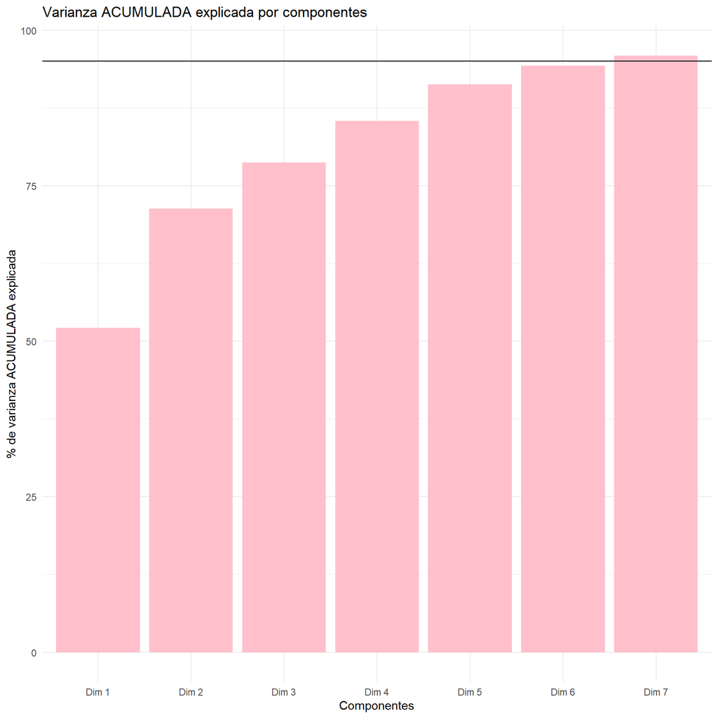

```r
cumvar <- as_tibble(pca_fit$eig)
names(cumvar) <- c("lambda", "var", "cumvar")

ggplot(cumvar[1:7, ],
       aes(x=1:7, y=cumvar)) +
  geom_col(fill = "pink") +
  geom_hline(yintercept = 95) + # pintar el 95%
  theme_minimal() +
  scale_x_discrete(limit = c("Dim 1","Dim 2","Dim 3","Dim 4","Dim 5","Dim 6","Dim 7")) +
  labs() +
  xlab("Componentes") +
  ylab("% de varianza ACUMULADA explicada") +
  ggtitle("Varianza ACUMULADA explicada por componentes")
```

> Visualiza la varianza explicada por cada componente haciendo uso de `fviz_eig()`. Personaliza el gráfico todo lo que consideres

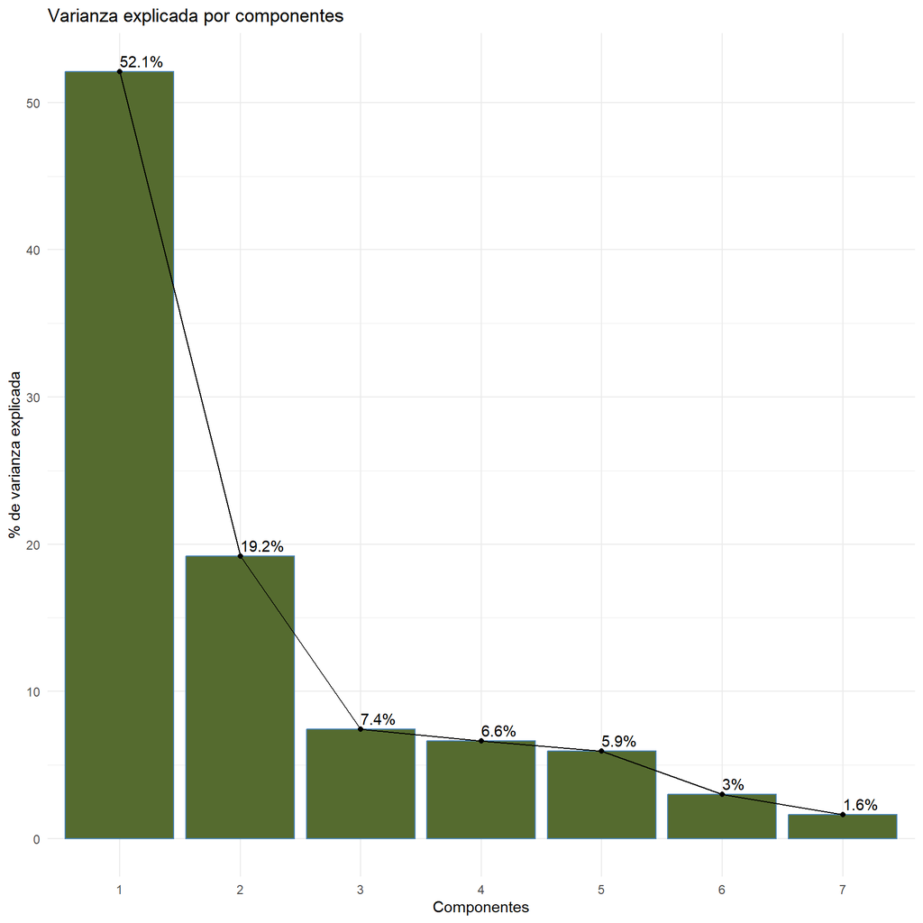

```r
fviz_eig(pca_fit,
         choice = "variance",
         ncp = 7, # esta vez queremos solo 7 comp
         barfill = "darkolivegreen",
         addlabels = TRUE) +
  theme_minimal() +
  labs() +
  xlab("Componentes") +
  ylab("% de varianza explicada") +
  ggtitle("Varianza explicada por componentes")
```

```r
pca_fit$ind$coord
```

```
        Dim.1      Dim.2       Dim.3       Dim.4      Dim.5
1  -0.1314916 -4.8942968  1.80708144 -2.16775933 -0.1800524
2  -2.0375151 -0.5157662 -0.37971970 -1.01703320 -1.7071126
3  -4.5855783  0.1651893 -1.38857721  0.10625838 -0.7697048
4  -4.3261015 -2.2337624 -0.52875655  0.15733411  0.8095421
5  -4.9667967 -0.2481768 -0.19600026  0.33349840  0.5453017
6   0.5323325 -2.8288665  0.60294068 -0.42431080 -0.3381237
7  -4.1941225 -2.7060224 -0.31370449  0.48555132  0.3683040
8  -3.0067743  2.8724330  3.09635105  2.91694564 -0.4667014
9  -3.9570682  0.7958991 -0.05166064  0.51357272  3.2148961
10  2.2898336 -0.1855328 -0.69262390  1.69010358 -1.7325771
11  3.8045727 -1.1055622  0.16287337  0.76775579 -0.9491509
12  5.3846198 -1.4338969  0.14347721  0.04734571  1.3700221
13  5.8922025 -0.9812260 -0.15835730  1.46908675  0.5905844
14  0.8440373  1.7732613 -3.18574227  0.22935416 -0.7625148
```

[output cut: 29 more lines]

```r
# los scores (ahora solo guardaríamos los de las 7 comps seleccionadas)

# los guardamos en formato tibble
pca_scores <- as_tibble(pca_fit$ind$coord)
pca_scores # Nuevas coordenadas (21 filas porque hay 21 observaciones originales!)
```

```
# A tibble: 21 × 7
    Dim.1  Dim.2   Dim.3  Dim.4  Dim.5  Dim.6  Dim.7
    <dbl>  <dbl>   <dbl>  <dbl>  <dbl>  <dbl>  <dbl>
 1 -0.131 -4.89   1.81   -2.17  -0.180  1.17   0.342
 2 -2.04  -0.516 -0.380  -1.02  -1.71   0.367  0.951
 3 -4.59   0.165 -1.39    0.106 -0.770 -0.586 -0.193
 4 -4.33  -2.23  -0.529   0.157  0.810 -0.335 -0.108
 5 -4.97  -0.248 -0.196   0.333  0.545 -0.894 -0.293
 6  0.532 -2.83   0.603  -0.424 -0.338 -0.855  0.347
 7 -4.19  -2.71  -0.314   0.486  0.368 -0.884  0.213
 8 -3.01   2.87   3.10    2.92  -0.467  0.666  0.813
 9 -3.96   0.796 -0.0517  0.514  3.21   0.740 -0.469
10  2.29  -0.186 -0.693   1.69  -1.73   0.651 -0.809
# … with 11 more rows
```

## Ejercicio 6.1

> Ejecuta el código inferior y detalla cada una de las salidas. Detalla todo lo que consideres. En particular, ¿qué distritos van a tener características similares? Justifica la respuesta

```r
pca_fit$ind$coord # este elemento contiene las coordenadas de nuestras observaciones
```

```
        Dim.1      Dim.2       Dim.3       Dim.4      Dim.5
1  -0.1314916 -4.8942968  1.80708144 -2.16775933 -0.1800524
2  -2.0375151 -0.5157662 -0.37971970 -1.01703320 -1.7071126
3  -4.5855783  0.1651893 -1.38857721  0.10625838 -0.7697048
4  -4.3261015 -2.2337624 -0.52875655  0.15733411  0.8095421
5  -4.9667967 -0.2481768 -0.19600026  0.33349840  0.5453017
6   0.5323325 -2.8288665  0.60294068 -0.42431080 -0.3381237
7  -4.1941225 -2.7060224 -0.31370449  0.48555132  0.3683040
8  -3.0067743  2.8724330  3.09635105  2.91694564 -0.4667014
9  -3.9570682  0.7958991 -0.05166064  0.51357272  3.2148961
10  2.2898336 -0.1855328 -0.69262390  1.69010358 -1.7325771
11  3.8045727 -1.1055622  0.16287337  0.76775579 -0.9491509
12  5.3846198 -1.4338969  0.14347721  0.04734571  1.3700221
13  5.8922025 -0.9812260 -0.15835730  1.46908675  0.5905844
14  0.8440373  1.7732613 -3.18574227  0.22935416 -0.7625148
```

[output cut: 29 more lines]

```r
# (ie, de los distritos) en la nueva base de 7 comps principales. Por eso vemos en
# las cols las 7 Dims seleccionadas por el PCA, y en las filas tenemos las 21 observaciones.

# Por ej, en nuestro dataset original en la fila 1 tenemos los valores del distrito
# "CENTRO" para las variabs orig. Pues en esta salida, en la fila 1, tenemos los
# valores del distrito "CENTRO" para las 7 comps principales seleccionadas.

pca_fit$ind$cos2 # en términos cualitativos, este elemento aporta una estimación
```

```
          Dim.1        Dim.2        Dim.3        Dim.4        Dim.5
1  0.0004986259 6.908109e-01 9.417465e-02 1.355192e-01 0.0009349239
2  0.3811089780 2.442043e-02 1.323652e-02 9.495499e-02 0.2675296016
3  0.8544736502 1.108854e-03 7.835208e-02 4.588142e-04 0.0240745875
4  0.7286291826 1.942617e-01 1.088491e-02 9.637379e-04 0.0255147920
5  0.9080443489 2.267132e-03 1.414059e-03 4.093943e-03 0.0109453101
6  0.0269018078 7.596971e-01 3.451157e-02 1.709164e-02 0.0108534231
7  0.6501962356 2.706606e-01 3.637506e-03 8.714300e-03 0.0050138931
8  0.2403453266 2.193481e-01 2.548792e-01 2.261990e-01 0.0057904488
9  0.5475024759 2.214905e-02 9.331652e-05 9.222378e-03 0.3613872983
10 0.3926155185 2.577515e-03 3.592151e-02 2.138879e-01 0.2247733212
11 0.7786456163 6.574980e-02 1.427014e-03 3.170840e-02 0.0484616991
12 0.8307836739 5.891335e-02 5.898529e-04 6.423019e-05 0.0537815171
13 0.8768671461 2.431737e-02 6.333659e-04 5.450965e-02 0.0088093191
14 0.0416035319 1.836337e-01 5.926908e-01 3.071992e-03 0.0339549787
```

[output cut: 29 more lines]

```r
# de la calidad de representación, es decir, nos da una indicación de lo bien
# representada que está una observación en las comps principales (de tal manera
# que, a mayor valor de cos2, mejor representada está).

# Cada observación (las 21 filas) tiene un valor de cos2 asociado a cada comp
# (las 7 cols), de modo que una observación puede estar mejor representada en una
# comp, pero peor en otra. Por ej,el distrito 17 tiene el cos2 más alto en
# Dim.1 (0.929), pero también tiene el más bajo en Dim.2 (1.099e-05). De hecho,
# más adelante veremos la representación gráfica de los distritos en las
# comps 1 y 2, y podremos ver que el distrito 17 tiene un score alto en
# la Dim.1, mientras que su score en Dim.2 es prácticamente nulo (recoredemos que
# también disponemos de los valores exactos de los scores).

# En otras palabras, la información de la observación 17 está bien representada
# en la comp 1, pero mal representada en la comp 2.

pca_fit$ind$contrib # la contribución representa lo mismo que el cos2, pero
```

```
          Dim.1        Dim.2       Dim.3        Dim.4      Dim.5
1   0.006868533 2.582714e+01  9.10304525 14.669870181  0.1130999
2   1.649185161 2.868147e-01  0.40193655  3.229047280 10.1669059
3   8.353259464 2.942114e-02  5.37491146  0.035247679  2.0668686
4   7.434660626 5.379843e+00  0.77936837  0.077276942  2.2863533
5   9.799874351 6.640765e-02  0.10708892  0.347209540  1.0373809
6   0.112572850 8.628207e+00  1.01339889  0.562046588  0.3988556
7   6.987953000 7.895114e+00  0.27432963  0.735994262  0.4732355
8   3.591446503 8.896014e+00 26.72585673 26.562002592  0.7598759
9   6.220349999 6.829858e-01  0.00743962  0.823394655 36.0577265
10  2.082934446 3.711395e-02  1.33729185  8.917246778 10.4724821
11  5.750154561 1.317838e+00  0.07394884  1.840137763  3.1429324
12 11.518020030 2.216825e+00  0.05738483  0.006997864  6.5481655
13 13.791867568 1.038087e+00  0.06990487  6.737503883  1.2168256
14  0.283003014 3.390323e+00 28.29127528  0.164216721  2.0284348
```

[output cut: 29 more lines]

```r
# expresado en porcentaje, de tal modo que las contribuciones de las 21 observaciones
# a cada comp principal suman 100%.

# colSums(pca_fit$ind$contrib) # comprobación de que suman 100%

# Siguiendo con el ejemplo del distrito 17, vemos que su contrib a la comp 1
# es 11.94%, mientras que en la comp 2 es prácticamente 0%.

# ¿Qué distritos van a tener características similares?
# RESPUESTA:
# Lógicamente, los distritos que tengan coordenadas similares en la nueva base
# de comps principales tendrán características similares (ie, valores similares
# de las variabs orig).
```

## Ejercicio 6.2

> Ejecuta el código inferior y detalla cada una de las salidas. Detalla todo lo que consideres. En particular, ¿qué variables van a estar mejor representadas (la información que contienen) si hacemos uso solo de las 2 primeras componentes? Justifica tu respuesta

```r
# La siguientes salidas explican los mismos 3 elementos que las del apartado
# anterior, solo que ahora referidas a las variabs orig en lugar de a las
# observaciones (ahroa tendremos tablas con las 23 variabs y las 7 comps):

pca_fit$var$coord # si los autovectores (loadings) eran las coordenadas de las
```

```
                    Dim.1       Dim.2       Dim.3        Dim.4
Superficie    -0.15578866  0.49313316  0.59638616  0.434893725
Densidad      -0.17370371 -0.87010139 -0.23797452 -0.019660734
Pob_0_14       0.19226125  0.81996391  0.40015762 -0.005818047
Pob_15_29      0.57956589 -0.48822427 -0.16832148 -0.071638861
Pob_30_44      0.03192588 -0.55354501  0.64673530 -0.425063328
Pob_45_64      0.53928105  0.37218702 -0.41456329 -0.321130875
Pob_65+       -0.59122013 -0.13969657 -0.54785869  0.502189653
N_Española    -0.73316534  0.56125890 -0.23632411  0.127961538
Extranjeros    0.70836607 -0.63381067  0.18091788 -0.040313145
N_ hogares     0.14052990 -0.39681219  0.22275364  0.687012001
Renta         -0.94563475  0.08284075 -0.01761562  0.095183843
T_paro         0.99197204 -0.01988377 -0.01248057  0.030778709
T_paro_H       0.98937581  0.05984964  0.01263892  0.011987373
T- paro_M      0.97853703 -0.12243240 -0.04140315  0.048619321
Paro_LD        0.51744403  0.57854783 -0.05838360  0.125394074
Analfabetos    0.95412663  0.19972112 -0.03215494  0.104180162
Primaria_ inc  0.95625861  0.10212714 -0.11459327  0.212727487
ESO            0.97749084  0.15024471 -0.01537351  0.087567050
fp_bach        0.17953630  0.65286681 -0.19501920 -0.356477629
T_medios      -0.85885724  0.32120690  0.04390461 -0.260994547
T_superiores  -0.95031595 -0.27365185  0.06638136 -0.061186586
S_M2_vivienda -0.69154367  0.27406060  0.11183256  0.114349490
Valor_V       -0.91948721 -0.23265506 -0.04442996 -0.026068319
                     Dim.5        Dim.6        Dim.7
Superficie    -0.016913572  0.188041272  0.208139784
Densidad      -0.198013720 -0.191567697  0.168016589
Pob_0_14       0.129748226 -0.103164250 -0.159296298
Pob_15_29      0.557428729  0.106854220  0.110562833
Pob_30_44     -0.205594322 -0.125259513  0.099179238
Pob_45_64      0.145641654  0.414441373  0.274854370
Pob_65+       -0.181026243 -0.047711021 -0.124139902
N_Española    -0.123844603 -0.135408362  0.137080685
Extranjeros    0.082860439  0.104930224 -0.149711138
N_ hogares    -0.336635339  0.255154422  0.093569589
Renta          0.211963743 -0.042318672 -0.096304198
T_paro        -0.031368375 -0.044002054 -0.046141278
T_paro_H      -0.012494722 -0.078425825 -0.051937881
T- paro_M     -0.054071796  0.003749870 -0.035037329
Paro_LD        0.154881563 -0.476895124  0.243475172
Analfabetos    0.090158879 -0.083266542  0.002446751
Primaria_ inc  0.002999125  0.043008270 -0.052062330
ESO           -0.001499831 -0.033604654 -0.061350005
fp_bach       -0.502651507  0.154265317 -0.121077556
T_medios      -0.258649720  0.097671101  0.031559268
T_superiores   0.076942328 -0.009065895  0.063039064
S_M2_vivienda  0.552839740  0.161424804 -0.085256626
Valor_V        0.232127218 -0.055952082 -0.074365555
```

```r
# comps principales expresadas en la base de variabs orig, ahora lo que nos devuelve
# esta salida es lo contrario: las coords de las variabs orig expresadas en
# la base de comps principales (en cada fila, tenemos las 7 coords de una de
# las variabs orig).

pca_fit$var$cos2 # el cos2 nos da una estimación de lo bien representada que
```

```
                    Dim.1        Dim.2        Dim.3        Dim.4
Superficie    0.024270106 0.2431803093 0.3556764488 1.891326e-01
Densidad      0.030172978 0.7570764370 0.0566318711 3.865445e-04
Pob_0_14      0.036964387 0.6723408171 0.1601261200 3.384967e-05
Pob_15_29     0.335896621 0.2383629382 0.0283321200 5.132126e-03
Pob_30_44     0.001019262 0.3064120797 0.4182665477 1.806788e-01
Pob_45_64     0.290824055 0.1385231778 0.1718627195 1.031250e-01
Pob_65+       0.349541243 0.0195151316 0.3001491443 2.521944e-01
N_Española    0.537531421 0.3150115552 0.0558490866 1.637416e-02
Extranjeros   0.501782483 0.4017159686 0.0327312805 1.625150e-03
N_ hogares    0.019748651 0.1574599176 0.0496191845 4.719855e-01
Renta         0.894225081 0.0068625905 0.0003103102 9.059964e-03
T_paro        0.984008532 0.0003953645 0.0001557646 9.473289e-04
T_paro_H      0.978864486 0.0035819800 0.0001597422 1.436971e-04
T- paro_M     0.957534710 0.0149896934 0.0017142208 2.363838e-03
Paro_LD       0.267748328 0.3347175902 0.0034086443 1.572367e-02
Analfabetos   0.910357628 0.0398885276 0.0010339404 1.085351e-02
Primaria_ inc 0.914430532 0.0104299519 0.0131316173 4.525298e-02
ESO           0.955488345 0.0225734735 0.0002363449 7.667988e-03
fp_bach       0.032233283 0.4262350680 0.0380324885 1.270763e-01
T_medios      0.737635762 0.1031738698 0.0019276150 6.811815e-02
T_superiores  0.903100397 0.0748853331 0.0044064849 3.743798e-03
S_M2_vivienda 0.478232641 0.0751092124 0.0125065208 1.307581e-02
Valor_V       0.845456736 0.0541283749 0.0019740211 6.795573e-04
                     Dim.5        Dim.6        Dim.7
Superficie    2.860689e-04 3.535952e-02 4.332217e-02
Densidad      3.920943e-02 3.669818e-02 2.822957e-02
Pob_0_14      1.683460e-02 1.064286e-02 2.537531e-02
Pob_15_29     3.107268e-01 1.141782e-02 1.222414e-02
Pob_30_44     4.226903e-02 1.568995e-02 9.836521e-03
Pob_45_64     2.121149e-02 1.717617e-01 7.554492e-02
Pob_65+       3.277050e-02 2.276342e-03 1.541072e-02
N_Española    1.533749e-02 1.833542e-02 1.879111e-02
Extranjeros   6.865852e-03 1.101035e-02 2.241342e-02
N_ hogares    1.133234e-01 6.510378e-02 8.755268e-03
Renta         4.492863e-02 1.790870e-03 9.274498e-03
T_paro        9.839749e-04 1.936181e-03 2.129018e-03
T_paro_H      1.561181e-04 6.150610e-03 2.697543e-03
T- paro_M     2.923759e-03 1.406152e-05 1.227614e-03
Paro_LD       2.398830e-02 2.274290e-01 5.928016e-02
Analfabetos   8.128623e-03 6.933317e-03 5.986591e-06
Primaria_ inc 8.994751e-06 1.849711e-03 2.710486e-03
ESO           2.249492e-06 1.129273e-03 3.763823e-03
fp_bach       2.526585e-01 2.379779e-02 1.465977e-02
T_medios      6.689968e-02 9.539644e-03 9.959874e-04
T_superiores  5.920122e-03 8.219046e-05 3.973924e-03
S_M2_vivienda 3.056318e-01 2.605797e-02 7.268692e-03
Valor_V       5.388305e-02 3.130635e-03 5.530236e-03
```

```r
# está cada variab orig en cada comp principal (de tal manera que, a mayor valor
# de cos2, mejor representada está). Si una variab tiene un cos2 muy cercano a 0
# para cierta Dim, significa que esa Dim no captura la información de la variab,
# minetras que si es muy cercano a 1, significa que esa Dim y la variab reflejan
# prácticamente la misma información.

pca_fit$var$contrib # nuevamente, la contrib es el cos2 expresado en porcentaje,
```

```
                    Dim.1        Dim.2        Dim.3        Dim.4
Superficie    0.202469080  5.506090573 20.821195080 12.399087391
Densidad      0.251712749 17.141730945  3.315213137  0.025340950
Pob_0_14      0.308368885 15.223146338  9.373736139  0.002219105
Pob_15_29     2.802158379  5.397015618  1.658554001  0.336450193
Pob_30_44     0.008503012  6.937784841 24.485201127 11.844881325
Pob_45_64     2.426148439  3.136442937 10.060793236  6.760636157
Pob_65+       2.915986237  0.441861771 17.570642944 16.533277619
N_Española    4.484261173  7.132494237  3.269389161  1.073451286
Extranjeros   4.186031954  9.095656283  1.916079566  0.106541009
N_ hogares    0.164749646  3.565208757  2.904692522 30.942263869
Renta         7.459915187  0.155382830  0.018165469  0.593950024
T_paro        8.208917805  0.008951846  0.009118415  0.062104667
T_paro_H      8.166004503  0.081103220  0.009351260  0.009420447
T- paro_M     7.988064608  0.339396761  0.100349983  0.154967709
Paro_LD       2.233643252  7.578678445  0.199541037  1.030807254
Analfabetos   7.594498118  0.903156372  0.060526570  0.711530454
Primaria_ inc 7.628475597  0.236155056  0.768721028  2.966679689
ESO           7.970993166  0.511108774  0.013835559  0.502695362
fp_bach       0.268900482  9.650817932  2.226410730  8.330824746
T_medios      6.153596379  2.336063612  0.112842019  4.465666680
T_superiores  7.533955944  1.695554332  0.257954336  0.245434650
S_M2_vivienda 3.989571547  1.700623407  0.732128065  0.857219230
Valor_V       7.053073857  1.225575113  0.115558615  0.044550184
                     Dim.5        Dim.6        Dim.7
Superficie    2.095822e-02  5.138441238 11.601431226
Densidad      2.872595e+00  5.332975482  7.559719803
Pob_0_14      1.233351e+00  1.546619514  6.795364235
Pob_15_29     2.276473e+01  1.659236856  3.273555374
Pob_30_44     3.096749e+00  2.280061038  2.634164570
Pob_45_64     1.554014e+00 24.960382715 20.230502284
Pob_65+       2.400860e+00  0.330797679  4.126902116
N_Española    1.123668e+00  2.664501713  5.032153752
Extranjeros   5.030119e-01  1.600023010  6.002188057
N_ hogares    8.302391e+00  9.460873369  2.344611114
Renta         3.291599e+00  0.260249010  2.483658072
T_paro        7.208880e-02  0.281365560  0.570138818
T_paro_H      1.143765e-02  0.893805905  0.722386842
T- paro_M     2.142029e-01  0.002043419  0.328748179
Paro_LD       1.757451e+00 33.049949213 15.874890321
Analfabetos   5.955261e-01  1.007548803  0.001603175
Primaria_ inc 6.589811e-04  0.268799828  0.725852817
ESO           1.648042e-04  0.164105789  1.007930487
fp_bach       1.851048e+01  3.458291731  3.925804477
T_medios      4.901261e+00  1.386299929  0.266719773
T_superiores  4.337250e-01  0.011943907  1.064194186
S_M2_vivienda 2.239145e+01  3.786740722  1.946514542
Valor_V       3.947625e+00  0.454943571  1.480965779
```

```r
# por lo que vuelve a reflejar la calidad de representación de cada variab en cada comp.

# colSums(pca_fit$var$contrib) # suman 100%

# ¿Qué variables van a estar mejor representadas si hacemos uso solo de las 2 primeras componentes?
# RESPUESTA:
# Las variabs mejor representadas en Dim.1 y Dim.2 son las que mayor valor de
# cos2 total tengan para esas comps.

as.data.frame(rowSums(pca_fit$var$cos2[,c(1,2)])) %>%
  slice_max(rowSums(pca_fit$var$cos2[,c(1,2)]),
            n = 6)
```

```
             rowSums(pca_fit$var$cos2[, c(1, 2)])
T_paro                                  0.9844039
T_paro_H                                0.9824465
ESO                                     0.9780618
T_superiores                            0.9779857
T- paro_M                               0.9725244
Analfabetos                             0.9502462
```

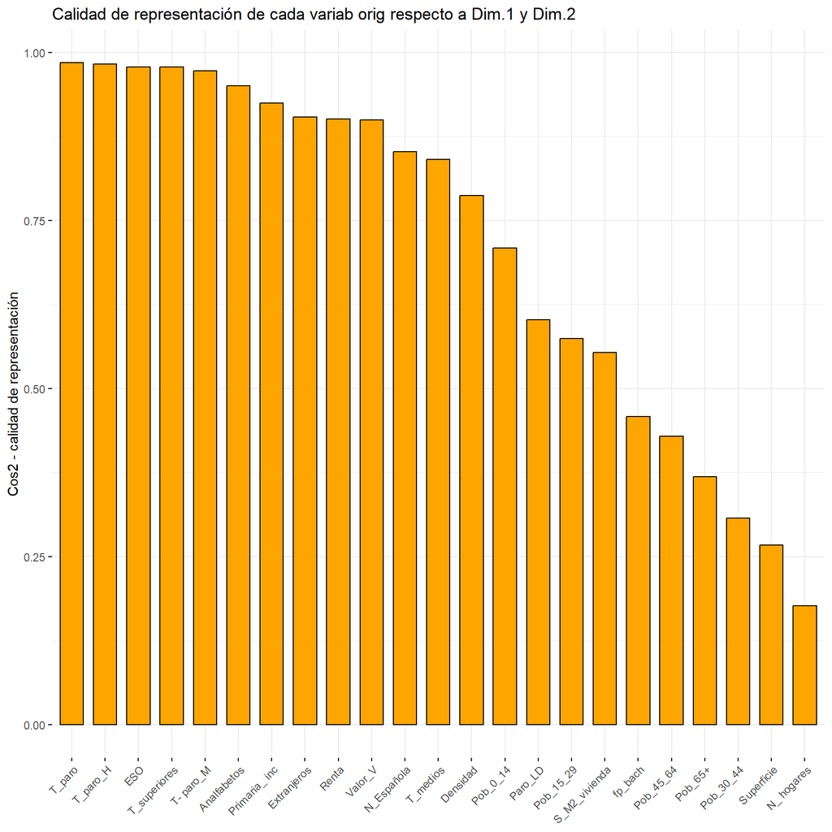

```r
# Luego las variabs mejor representadas son: T_paro, T_paro_H, ESO, T_superiores y T- paro_M.

# También podemos verlo visualmente con:
fviz_cos2(pca_fit, choice = "var", axes = 1:2, # cos2 total de las variabs para comps 1 y 2
          title = "Calidad de representación de cada variab orig respecto a Dim.1 y Dim.2",
          color = "black",
          fill = "orange") +
          ylab("Cos2 - calidad de representación")
```

```r
# Nota adicional: también podemos verlo con el gráfico 'fviz_pca_var' (representando
# Dim.1 y Dim.2 y fijándolos en el "peso") que veremos más adelante.
```

# Ejercicio 7

> Realiza de nuevo el análisis pero introduciendo todas las variables, incluyendo las cualitativas (sin que sean usadas en la construcción de las nuevas direcciones pero que luego podamos obtener dichas variables proyectadas), con el número de componentes determinadas anteriormente para explicar el 95% de la varianza.

```r
pca_fit <-
  PCA(distritos,
      quali.sup = c(1,25), # le indicamos las variabs categóricas suplementarias!!!
      scale.unit = TRUE, ncp = 7, # 7 comps
      graph = FALSE)
```

## Ejercicio 7.1

> Ejecuta `fviz_pca_var()` para visualizar las variables respecto a las dos primeras componentes. Asigna el color de las flechas de tal manera que corresponda al módulo (longitud) de la misma. Cambia la paleta de colores que usa para el gradiente de colores como consideres. Detalla todo lo que consideres, en concreto la correlación o independencia lineal de las variables. ¿Qué variables tienen un comportamiento similar? ¿Cuáles están mejor representadas (usando solo las dos primeras componentes)? Prueba a usar también `fviz_cos2()`

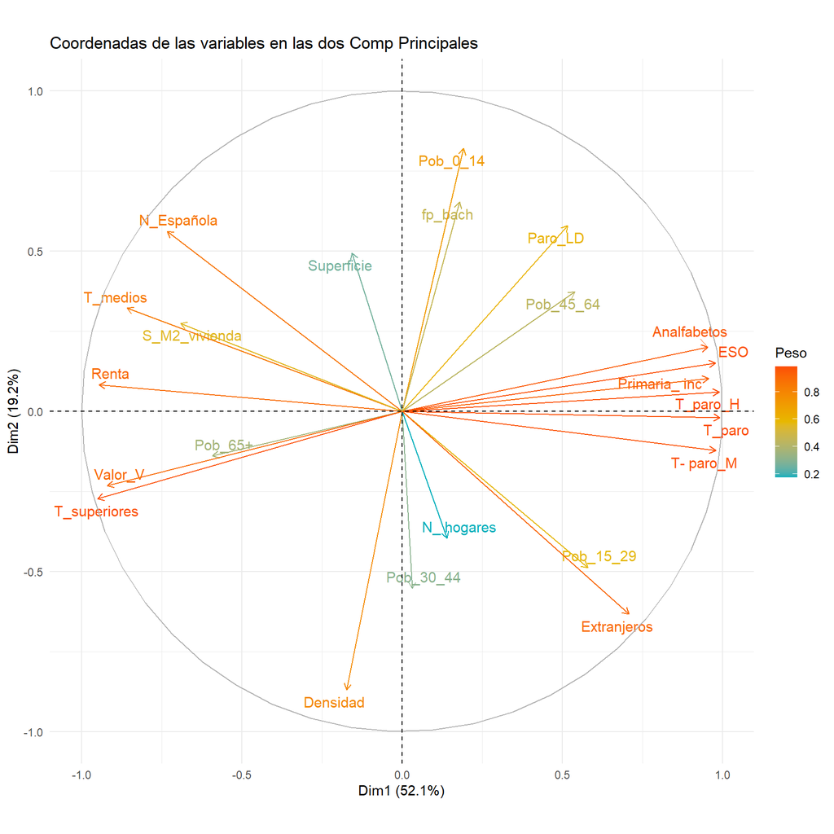

```r
col <- c("#00AFBB", "#E7B800", "#FC4E07")

fviz_pca_var(pca_fit, col.var = "cos2", # por dfto axes = 1:2 (comps 1 y 2)
             gradient.cols = col,
             repel = TRUE) +
  theme_minimal() +
  labs(color= "Peso") +
  ggtitle("Coordenadas de las variables en las dos Comp Principales")
```

```r
# [Recordemos que estamos pasando de un espacio n-dimensional (cuya base está
# dada por las n variables orig) a un espacio n-dimensional (pero con una base
# distinta, de n comps), y luego al seleccionar menos comps principales, lo que
# hacemos es reducir la dimensionalidad de ese espacio, y por tanto se pierde
# info al tener que proyectar todas las observaciones de una base a otra con
# menos dimensiones. En gráfico nos sirve para hacer un análisis cualitativo
# y visual de qué variabs están bien reflejadas en las Dim 1 y 2 representadas,
# y cuáles están peor representadas]

# Las variabs cuyo peso es muy cercano a 1 (al círculo de radio 1) son variabs
# explicadas casi por completo por las comps "Dim 1" y "Dim 2". Por tanto, tienen
# una alta correlación con las mismas (que será corr positiva o negativa en función
# de si la flecha de la variab apunta en elsentido positivo o negativo de la
# componente con la que estemos contrastando), mientras que son bastante
# independientes del resto de nuevas componentes.

# Las variabs ESO, Primaria_ inc, T_paro, T_paro_H y T- paro_M apuntan en el
# sentido positivo de Dim 1, y todas con pesos muy elevados. En otras palabras,
# todas ellas tienen efectos muy similares sobre nuestra variable Objetivo
# "Partido". Lógicamente, al ser tan similares a Dim 1, tienen una corr alta
# con ella, y por su parte, su corr con Dim 2 es menor.

# Podemos razonarlo de forma similar para todas las variables.

# Respecto a la calidad de la representación de las variabs en las comps 1 y 2,
# ya lo vimos en el EJERCICIO 6.2, cuando representamos el gráfico 'fviz_cos2'.
```

## Ejercicio 7.2

> Ejecuta `fviz_pca_ind()` para visualizar a los distritos respecto a las dos primeras componentes. Usa la variable de partido para visualizar en dos colores distintos los individuos. ¿Qué distritos tienen características similares? Analiza todo lo que consideres

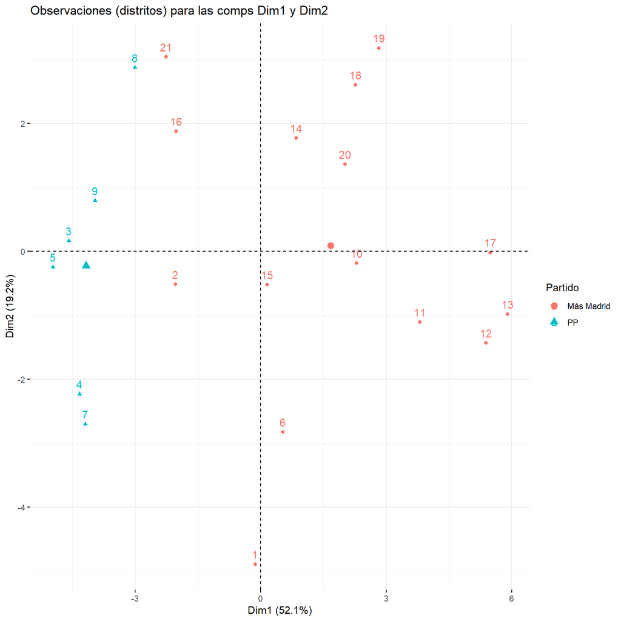

```r
fviz_pca_ind(pca_fit,
             axes = c(1,2), # c(x,y) Dim_x & Dim_y a representar (gráfico bidim)
             habillage = "Partido",
             title = "Observaciones (distritos) para las comps Dim1 y Dim2")
```